# Animal bites analysis

Will Canniford

## Introduction

We were provided with some information with the data set from Kaggle.

### Context

In the United States, animal bites are often reported to law enforcement (such as animal control). The main concern with an animal bite is that the animal may be rabid. This dataset includes information on over 9,000 animal bites which occurred near Louisville, Kentucky from 1985 to 2017 and includes information on whether the animal was quarantined after the bite occurred and whether that animal was rabid.

### Content

Attributes of animal bite incidents reported to and investigated by Louisville Metro Department of Public Health and Wellness. Personal/identifying data has been removed. This dataset is a single .csv with the following fields.

**bite_date**: The date the bite occurred  
**SpeciesIDDesc**: The species of animal that did the biting  
**BreedIDDesc**: Breed (if known)  
**GenderIDDesc**: Gender (of the animal)  
**color**: color of the animal  
**vaccination_yrs**: how many years had passed since the last vaccination  
**vaccination_date**: the date of the last vaccination  
**victim_zip**: the zipcode of the victim  
**AdvIssuedYNDesc**: whether advice was issued  
**WhereBittenIDDesc**: Where on the body the victim was bitten  
**quarantine_date**: whether the animal was quarantined  
**DispositionIDDesc**: whether the animal was released from quarantine  
**head_sent_date**: the date the animal’s head was sent to the lab  
**release_date**: the date the animal was released  
**ResultsIDDesc**: results from lab tests (for rabies)

## Load the data

Let’s start by loading in the packages that we are going to be using throughout the analysis.

```r
library(tidyverse)
library(ggplot2)
library(readr)
library(stringr)
library(lubridate)
library(gridExtra)
```

All of our data is contained within a single spreadsheet, so we can simply read that in using the `read_csv` function from the `readr` package.  
*Please note: I have specified the column types for two of the columns: `BreedIDDesc` and `release_date`. This is because I was encountering a problem where those columns were being read in as col_logical and nothing was parsing.*

```r
full_data <- read_csv('./input/Health_AnimalBites.csv', col_types = list(BreedIDDesc = col_character(), release_date = col_datetime()))
```

Let’s have a glimpse at the data to get an idea about what we are working with.

```r
glimpse(full_data)
```

```
## Observations: 9,003
## Variables: 15
## $ bite_date         <dttm> 1985-05-05, 1986-02-12, 1987-05-07, 1988-10...
## $ SpeciesIDDesc     <chr> "DOG", "DOG", "DOG", "DOG", "DOG", "DOG", "D...
## $ BreedIDDesc       <chr> NA, NA, NA, NA, NA, NA, NA, NA, NA, NA, NA, ...
## $ GenderIDDesc      <chr> "FEMALE", "UNKNOWN", "UNKNOWN", "MALE", "FEM...
## $ color             <chr> "LIG. BROWN", "BRO & BLA", NA, "BLA & BRO", ...
## $ vaccination_yrs   <int> 1, NA, NA, NA, NA, NA, 1, NA, NA, NA, NA, NA...
## $ vaccination_date  <dttm> 1985-06-20, NA, NA, NA, NA, NA, 1990-02-13,...
## $ victim_zip        <chr> "40229", "40218", "40219", NA, NA, "40211", ...
## $ AdvIssuedYNDesc   <chr> "NO", "NO", "NO", "NO", "NO", "NO", "NO", "N...
## $ WhereBittenIDDesc <chr> "BODY", "BODY", "BODY", "BODY", "BODY", "BOD...
## $ quarantine_date   <dttm> 1985-05-05, 1986-02-12, 1990-05-07, 1990-10...
## $ DispositionIDDesc <chr> "UNKNOWN", "UNKNOWN", "UNKNOWN", "UNKNOWN", ...
## $ head_sent_date    <dttm> NA, NA, NA, NA, NA, NA, NA, NA, NA, NA, NA,...
## $ release_date      <dttm> NA, NA, NA, NA, NA, NA, NA, NA, NA, NA, NA,...
## $ ResultsIDDesc     <chr> "UNKNOWN", "UNKNOWN", "UNKNOWN", "UNKNOWN", ...
```

We have just over 9,000 observations and 15 variables. We seem to have a mixture of categorical, numeric, and date columns.

### Missing data

Let’s run a quick `map_df` to see how many `NA` values are in each column.

```r
missing_stats <- purrr::map_df(full_data, ~ sum(is.na(.))) %>%
  gather('Column', 'na_count')

print(missing_stats)
```

```
## # A tibble: 15 x 2
##    Column            na_count
##    <chr>                <int>
##  1 bite_date              317
##  2 SpeciesIDDesc          118
##  3 BreedIDDesc           5244
##  4 GenderIDDesc          2526
##  5 color                 2576
##  6 vaccination_yrs       5265
##  7 vaccination_date      4888
##  8 victim_zip            1838
##  9 AdvIssuedYNDesc       6438
## 10 WhereBittenIDDesc      616
## 11 quarantine_date       6983
## 12 DispositionIDDesc     7468
## 13 head_sent_date        8608
## 14 release_date          7558
## 15 ResultsIDDesc         7460
```

So it looks like we are dealing with lots of NA values in this data set. We don’t know how much of that is to do with data errors or if they are missing due to that particular variable not being applicable to that observation.

`bite_date` having missing values could be due to bad data keeping but could also be because of circumstances that means that the data just isn’t known.  
`vaccination_date` being `NA` may just indicate that the animal was never vaccinated.

## Bites over time

```r
full_data$bite_date[which(full_data$bite_date > ymd('2018-01-01'))]
```

```
## [1] "2101-02-18 UTC" "2021-04-22 UTC" "2020-08-08 UTC" "5013-07-15 UTC"
## [5] "2201-01-21 UTC" "2201-02-21 UTC" "2201-05-01 UTC" "2018-04-17 UTC"
```

There doesn’t appear to be any obvious standard input problem for these values, so we can’t infer what dates they should be. We can take a guess that perhaps the 2201 and 2021 are meant to be 2012, but we cannot be certain.  
For the sake of this analysis of bite dates, I’ll simply remove them for plotting purposes.

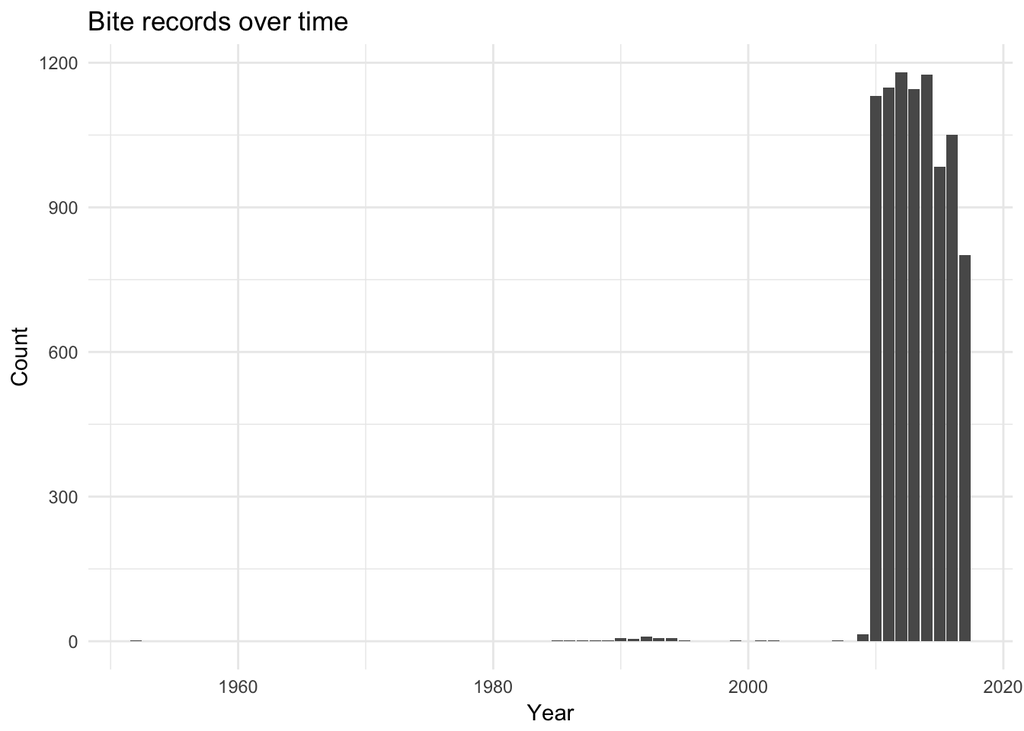

```r
full_data %>%
  filter(bite_date < ymd('2018-01-01')) %>% # Filter the data
    ggplot(aes(year(bite_date))) +
    geom_bar() +
    labs(x = 'Year', y = 'Count', title = 'Bite records over time') +
    theme_minimal()
```

There is definitely a huge cluster of bite records after 2010. This is probably due to an increase in the recording of the events, or a change in the method of recording, rather than a sudden jump in the number of incidents.

We can also view a potential outlier that is old, rather than the ones that we have found because they were in the future. A record that is back in the 1950s, 30 years before any of our other recorded bites.

## Considering the time of bites

### Month

Let’s have a deeper look into when these bites are occurring and see if we can find some patterns.

```r
month_data <- full_data %>%
  filter(bite_date < ymd('2018-01-01')) %>% # Remove those future observations
  group_by(month = month(bite_date)) %>% # Group by the month
  summarise(n_incidents = n()) %>% # Count observations
  transmute(month = ymd(paste('2018', month, '01', sep = '-')), n_incidents) # Create a month date object with lubridate

head(month_data)
```

| month | n_incidents |
| --- | --- |
| 2018-01-01 | 556 |
| 2018-02-01 | 534 |
| 2018-03-01 | 743 |
| 2018-04-01 | 845 |
| 2018-05-01 | 944 |
| 2018-06-01 | 920 |

We have made all the objects have the year of 2018. For this plot it doesn’t matter as we are focussing on the month of the bite rather than the year.

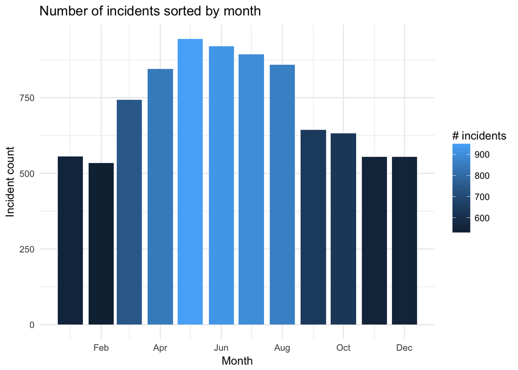

```r
month_data %>%
    ggplot(aes(x = month, y = n_incidents, fill = n_incidents)) +
    geom_col() +
    labs(x = 'Month', y = 'Incident count', title = "Number of incidents sorted by month") +
    scale_x_date(date_labels = '%b', date_breaks = '2 month', date_minor_breaks = '1 month') + # Show just the month
    scale_fill_continuous(name = '# incidents') +
    theme_minimal()
```

As you can see from this plot, it is clear to see that there are more incidents during the summer months. I would assume that this is down to higher exposure to potential incidents rather than a higher rate. Although, this is pure speculation.

### Day of the week

Let’s focus on the day of the week now and see if there are days of the week that account for higher numbers of bites.

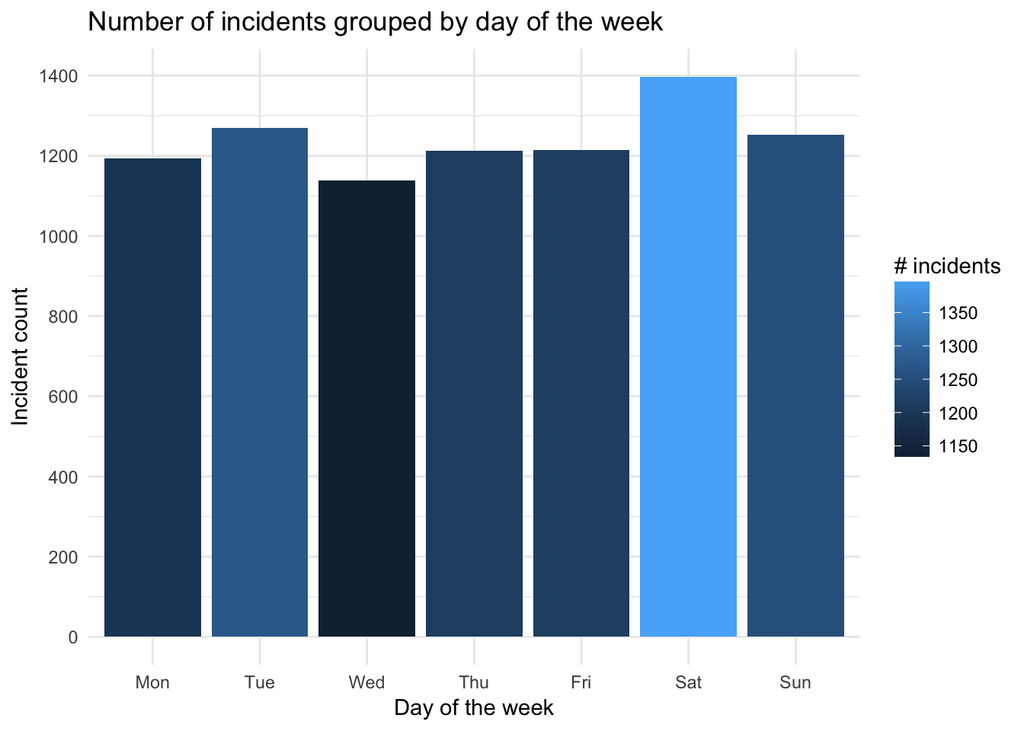

```r
full_data %>%
  filter(bite_date < ymd('2018-01-01')) %>%
    ggplot(aes(wday(bite_date, label = TRUE, week_start = 1), fill = ..count..)) +
    geom_bar() +
    labs(x = 'Day of the week', y = 'Incident count', title = "Number of incidents grouped by day of the week") +
    scale_fill_continuous(name = '# incidents') +
    theme_minimal() +
    scale_y_continuous(breaks = seq(0,1400,200))
```

## Species analysis

Perhaps instead of staying indoors throughout the weekends and summer, you could just be on the lookout for particular species.

Let’s have a look at the observations grouped by species. We can start by generating a simple grouped table of observation counts.

```r
species_counts <- full_data %>%
    group_by(SpeciesIDDesc) %>% # Group by species
    summarise(count = n()) %>%
    filter(!is.na(SpeciesIDDesc)) %>% # Remove those without a species
    arrange(desc(count)) # Most at the top

print(species_counts)
```

```
## # A tibble: 9 x 2
##   SpeciesIDDesc count
##   <chr>         <int>
## 1 DOG            7029
## 2 CAT            1568
## 3 BAT             237
## 4 RACCOON          27
## 5 OTHER            11
## 6 HORSE             5
## 7 FERRET            4
## 8 RABBIT            3
## 9 SKUNK             1
```

If we remove the NAs from the column then we can see below that the dog reigns supreme over the bite kingdom, followed by cat, and then the bat.

We can visualise the data to get a better intuition about how these species compare against one another.

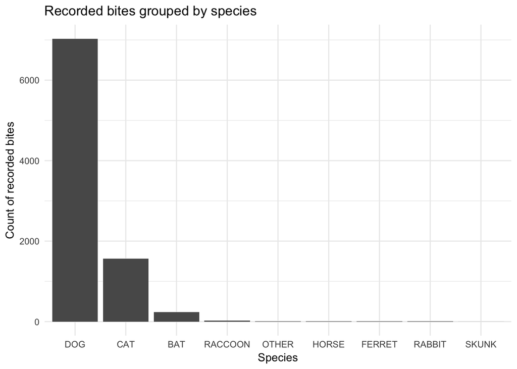

```r
species_counts %>%
  ggplot(aes(x = reorder(SpeciesIDDesc, desc(count)), y = count)) +
  geom_col() +
  labs(x = 'Species', y = 'Count of recorded bites', title = 'Recorded bites grouped by species') +
  theme_minimal()
```

## Breed analysis

Following the species analysis, we can see that the majority of the bites in the data have come from dogs.  
We can further investigate this through now looking at breeds and seeing how they compare against one another.

```r
breed_bites <- full_data %>%
  filter(!is.na(BreedIDDesc)) %>% # Remove those observations without breed
  group_by(BreedIDDesc) %>% # Group by breed
  summarise(count = n()) %>% # Get counts for each breed
  arrange(desc(count)) %>%
  top_n(10) # Get top 10 breeds by number of bites

print(breed_bites)
```

```
## # A tibble: 10 x 2
##    BreedIDDesc     count
##    <chr>           <int>
##  1 PIT BULL         1102
##  2 GERM SHEPHERD     327
##  3 LABRADOR RETRIV   253
##  4 BOXER             181
##  5 CHICHAUHUA        165
##  6 SHIH TZU          119
##  7 BEAGLE            116
##  8 ROTTWEILER         86
##  9 AAUST. TERR.       78
## 10 DACHSHUND          67
```

The comparison among breeds show that there is a clear prominence of bites from pit bulls. This is highlighted further when the results are visualised.

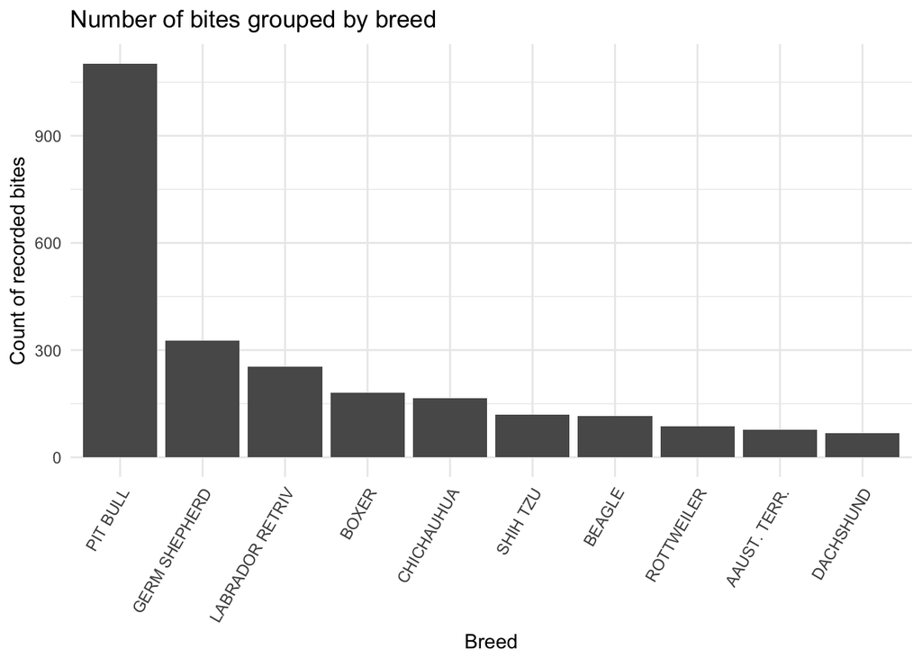

```r
breed_bites %>%
  ggplot(aes(x = reorder(BreedIDDesc, desc(count)), y = count)) +
  geom_col() +
  labs(x = 'Breed', y = 'Count of recorded bites', title = 'Number of bites grouped by breed') +
  theme_minimal() +
  theme(axis.text.x = element_text(angle = 60, hjust = 1))
```

## First the bite, then the test

We can have a look at the rabies test results column `ResultsIDDesc` to see how many of the rabies test results came back positive.

```r
table(full_data$ResultsIDDesc)
```

```
##
## NEGATIVE POSITIVE  UNKNOWN
##      299        4     1240
```

There were just four positive results for rabies out of all the bites in the data.

We can further investigate which animals have been tested, and if those animals, or species, have a particularly high prominence of rabies.

```r
full_data %>%
  filter(!is.na(ResultsIDDesc), !is.na(SpeciesIDDesc)) %>% # Must have a species and test result
  group_by(SpeciesIDDesc, ResultsIDDesc) %>% # Grouping
  summarise(count = n()) %>%
  spread(ResultsIDDesc, count) %>% # Change from long to wide format for printing
  filter(POSITIVE > 0) %>% # Remove those species without at least one positive result
  mutate(pos_perc = round(POSITIVE / (POSITIVE + NEGATIVE) * 100, 2)) # Calculate positive percentage
```

| SpeciesIDDesc | NEGATIVE | POSITIVE | UNKNOWN | pos_perc |
| --- | --- | --- | --- | --- |
| BAT | 160 | 3 | 17 | 1.84 |
| DOG | 58 | 1 | 979 | 1.69 |

Of those known results for the test, both bats and dogs are roughly 2% positive. Note the number of unknown for dogs in comparison to bats. It must be much more common practice to take the test and get the results if you are bitten by a bat when compared to a dog bite.

### Vaccination and test choice

What makes someone decide that they are going to get tested following an animal bite? The test doesn’t appear to be required otherwise every observation would have associated information about a test that had taken place.

Perhaps if you know that the animal has been vaccinated then you wouldn’t pursue the chance of rabies any further. This is only really relevant to domesticated animals who would be vaccinated in the first place, so we will focus on Dog bites.

```r
full_data %>%
  filter(SpeciesIDDesc == 'DOG', !is.na(ResultsIDDesc)) %>% # Dogs with a test result
  group_by(is.na(vaccination_date), ResultsIDDesc) %>% # Group by whether we have information about a vaccination date
  summarise(count = n()) %>%
  spread(ResultsIDDesc, count, fill = 0) %>% # Convert to long format for display
  mutate(test_perc = round((NEGATIVE + POSITIVE) / (NEGATIVE + POSITIVE + UNKNOWN) * 100, 2))
```

| is.na(vaccination_date) | NEGATIVE | POSITIVE | UNKNOWN | test_perc |
| --- | --- | --- | --- | --- |
| FALSE | 5 | 0 | 488 | 1.01 |
| TRUE | 53 | 1 | 491 | 9.91 |

If we are right that unknown means that no test was taken then we can see that people tended to opt for the test more if the dog hadn’t be vaccinated than if they knew that the dog had been vaccinated.

## Bite position

Another piece of information that we have access to in the data is the position of the bite.

We can use this to have a look and see if a particular species is typically involved in head bite incidents or body incidents.

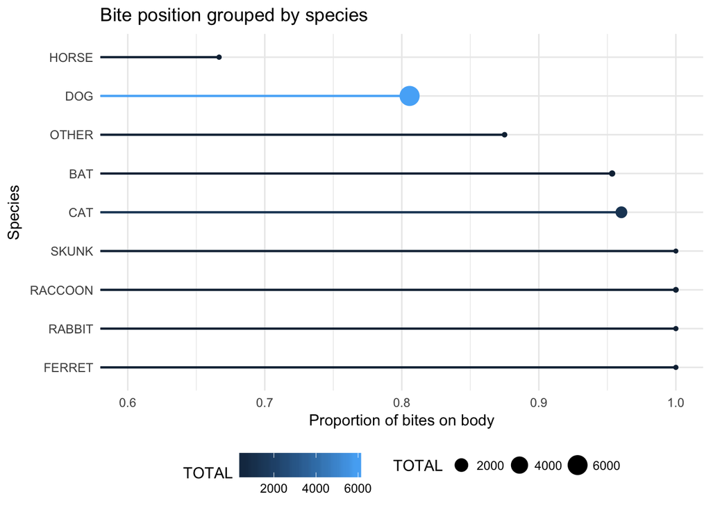

```r
full_data %>%
  group_by(SpeciesIDDesc, WhereBittenIDDesc) %>%
  filter(!is.na(WhereBittenIDDesc), !is.na(SpeciesIDDesc)) %>% # Observations with bite and species variables
  summarise(count = n()) %>%
  spread(WhereBittenIDDesc, count, fill = 0) %>% # Spread the data and fill unseen combinations with 0
  mutate(BODY_PROP = BODY/(BODY+HEAD), TOTAL = BODY + HEAD) %>% # Create proportion variable
  select(BODY_PROP, TOTAL) %>%
  ggplot() +
    geom_col(aes(x = reorder(SpeciesIDDesc, desc(BODY_PROP)), y = BODY_PROP, colour = TOTAL), width = .02) +
    geom_point(aes(x = reorder(SpeciesIDDesc, desc(BODY_PROP)), y = BODY_PROP, size = TOTAL, colour = TOTAL)) +
  coord_flip(ylim = c(.6, 1)) + # Flip the coordinates
  theme_minimal() +
  theme(legend.position = 'bottom') + # Move the legend
  labs(x = 'Species', y = 'Proportion of bites on body', title = 'Bite position grouped by species')
```

Horses have the highest proportion of bites that are recorded as the head, however they have a very small sample size. Of those bites where we know the position of the bite, the dog appears to have a high head proportion with almost 1 in 5 cases being face/head based. Perhaps this is people bending down to greet an unfriendly dog?

Bats and cats remain roughly the same level of head bites where we know the location. Skunk, raccoon, rabbit and ferret don’t have any recorded instances of face head/bites but the sample size for those species is much smaller.

## Aggressive males - gender analysis

Let’s investigate to see whether there is a difference in the bite count between the sexes of the offending animal.

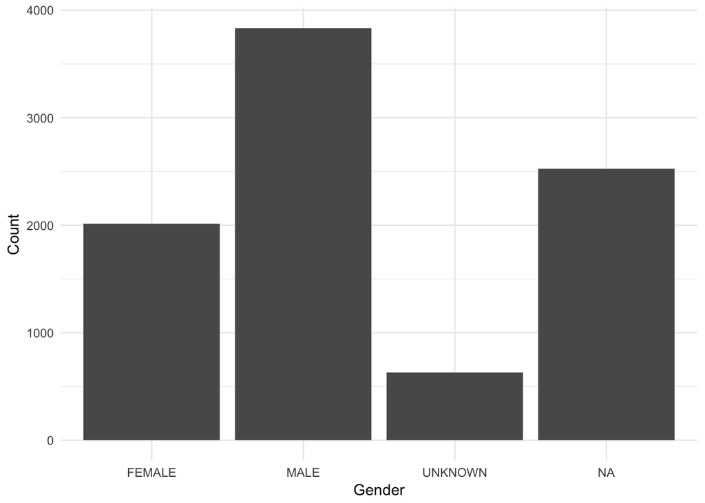

```r
ggplot(full_data, aes(x = as.factor(GenderIDDesc))) +
  geom_bar() +
  labs(x = 'Gender', y = 'Count') +
  theme_minimal()
```

The prominent gender of the biters is male here, but again with a surprising amount of `NA` values throughout the data set.

If we add some colour to this visualisation by the species of the animal, then we might find some patterns with this insight.

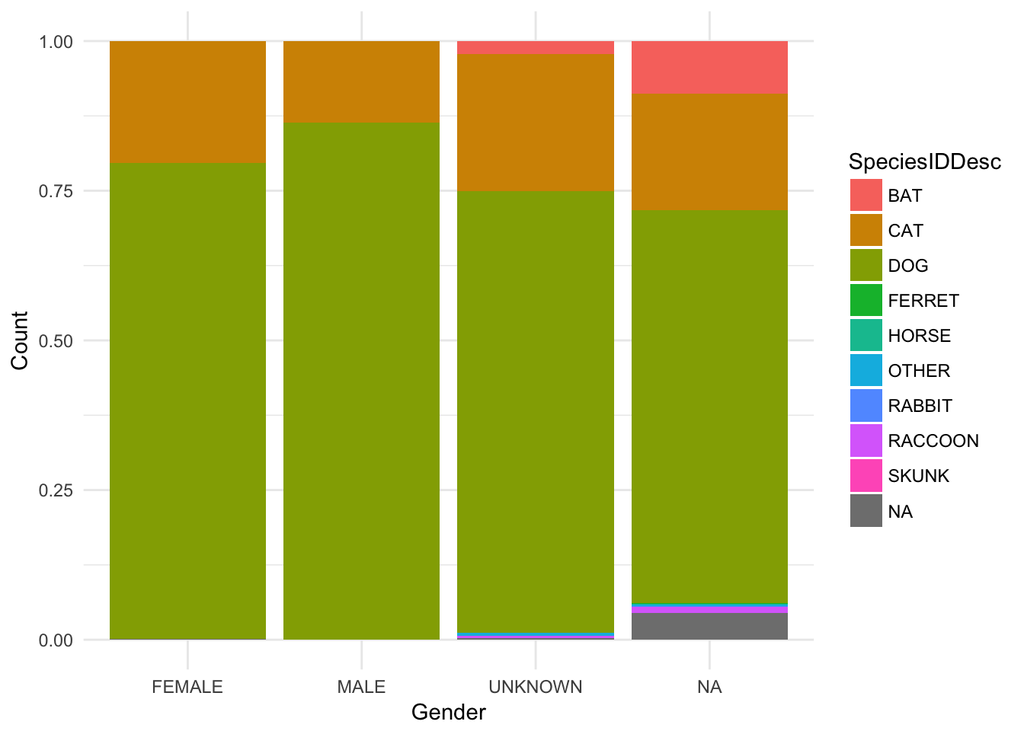

```r
ggplot(full_data, aes(x = as.factor(GenderIDDesc), fill = SpeciesIDDesc)) +
  geom_bar(position = 'fill') +
  labs(x = 'Gender', y = 'Count') +
  theme_minimal()
```

We see here that the species with less observations seem to appear in the `"UNKNOWN"` and `NA`. This is probably due to the fact that they don’t have access to the animal to establish its gender. This is even the case with the bat bites, as the recipient of the bite is not going to know that information when reporting it.

`NA` values here may well be equivalent to `"UNKNOWN"` and represent those instances where the gender of the animal could not be established or known. This perhaps makes sense given that an owner is going to know the gender of their pet and would be able to report that when bitten; i.e. cats and dogs.

## Conclusions

Thanks for taking the time to have a look at my analysis. If you have any feedback or advice, then I would love to hear it.